# Sesión 1: Estadistica Básica

Miguel Albertí Pons & Iker González Cuellar

05-11-22

```r
library(DescTools)
library(dplyr)
```

```r
library(magrittr)
setwd('D:/iCloud/iCloudDrive/Master Big Data/Data Analytics - Teoria_Practica/_r_exercises/2-ExerciseIntroStatistics')
```

#### **1. Calcular la media, la mediana, la desviación tipo, el primer cuartil, el tercer cuartil, el rango intercuartílico y dibujar el correspondiente boxplot, de la siguiente muestra de precios de pisos (de 3 habitaciones): 7.80, 12.60, 15.96, 13.50, 8.25, 31.29, 16.46**

```r
PreciosPisos = data.frame('precio' = c(7.80, 12.60, 15.96, 13.50, 8.25, 31.29, 16.46))

cat("Estadisticas descriptivas:\n",
"media:", mean(PreciosPisos$precio),"\n",
"mediana:",median(PreciosPisos$precio),"\n",
"Desviación Tipo:", sd(PreciosPisos$precio),"\n",
"Q1:", summary(PreciosPisos$precio)[2],"\n",
"Q3:", summary(PreciosPisos$precio)[5],"\n",
"IQR:", summary(PreciosPisos$precio)[5] - summary(PreciosPisos$precio)[2],"\n")
```

```
## Estadisticas descriptivas:
##  media: 15.12286
##  mediana: 13.5
##  Desviación Tipo: 7.892234
##  Q1: 10.425
##  Q3: 16.21
##  IQR: 5.785
```

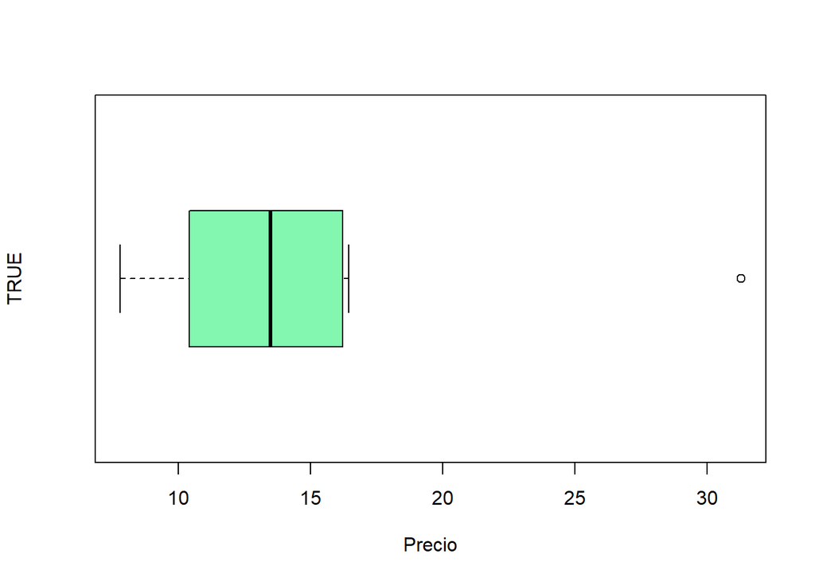

```r
boxplot(PreciosPisos$precio, horizontal=T, col = "#83F7AF", xlab = "Precio", ylab = T)
```

#### **2. Diga que razones le parecen convincentes para justificar que la media de una muestra escogida al azar es un estimador más fiable que la media de una muestra de expertos.**

- La media de una muestra *escogida al azar*, será siempre un estimador fiable cuando la muestra sea seleccionada de forma aleatoria cumpliendo los criterios de independencia y deversidad de la muestra en cuestión ya que de esta forma se permite tener un cierto grado de control sobre el margen de error.
- La media de una muestra seleccionada *por expertos* introduce sesgo ya que la muestra no es seleccionada de forma aleatoria, sino por un criterio pre-definido hacia un grupo específico anulando la posibilidad de controlar los margenes de error por el bias del experto resultando en una muestra no representativa.

#### **3. Suponga la variable aleatoria “tiempo que tardo en ir de mi casa al trabajo” y diferencie factores sistemáticos y factores aleatorios intervinientes en su medición.**

Sí en el día a día vuelvo a casa en bicicleta désde la universidad y quiero saber cuanto tiempo tardo, tendré que tener en cuenta diferentes factores:

*Factores sistemáticos:*

- Disponibilidad de bicicletas (usuarios bicing)
- Hora de salida
- Semaforos en la ruta hacia el destino
- Distancia a recorrer al trabajo según la ruta

*Factores aleatorios:*

- Alteraciones viales como por ejemplo cortes de calles por razones externas (e.g manifestaciones, reparaciones, etc)
- Condiciones climaticas
- Accidente ocacionados por 3eras personas
- Averías por condiciones externas

#### **4. Cuando podemos asegurar que el mecanismo generador de una variable aleatoria se aproxima a una distribución gaussiana.**

Se puede asegurar que el mecanismo generador de una variable aleatoria se aproxima a una distribución gaussiana cuando el ruido de la muestra tiene una cantidad considerable de factores irrelevantes y que todos estos factores irrelevantes tengan un nivel de importancia similar.

#### **5. Lea el fichero “BCN_pisos.txt”. Efectúe un summary de las variables leídas. Detecte si en el fichero proporcionado hay registros duplicados y elimínelos. Los datos proporcionados son reales. ¿Porque cree que existen registros duplicados?.**

```r
BcnPisos = read.delim("_2ex_repository/bcn_pisos.txt")

summary(BcnPisos)
```

```
##      Valor              Superf            Dorm           Banys
##  Min.   : 3007368   Min.   : 23.24   Min.   :1.000   Min.   :1.000
##  1st Qu.:12025000   1st Qu.: 64.20   1st Qu.:2.000   1st Qu.:1.000
##  Median :15456000   Median : 78.54   Median :3.000   Median :1.000
##  Mean   :17823727   Mean   : 83.97   Mean   :2.903   Mean   :1.319
##  3rd Qu.:20920248   3rd Qu.: 95.00   3rd Qu.:3.000   3rd Qu.:2.000
##  Max.   :99662144   Max.   :475.30   Max.   :5.000   Max.   :4.000
##       Edat           Estat              Planta              Dist
##  Min.   :  0.00   Length:2329        Length:2329        Length:2329
##  1st Qu.: 25.00   Class :character   Class :character   Class :character
##  Median : 30.00   Mode  :character   Mode  :character   Mode  :character
##  Mean   : 40.75
##  3rd Qu.: 50.00
##  Max.   :289.00
##      ValSol          Tipus              Ascens             ExtInt
##  Min.   : 20321   Length:2329        Length:2329        Length:2329
##  1st Qu.:106679   Class :character   Class :character   Class :character
##  Median :119965   Mode  :character   Mode  :character   Mode  :character
##  Mean   :128708
##  3rd Qu.:146537
##  Max.   :365754
##    Reforma
##  Length:2329
##  Class :character
##  Mode  :character
##
##
##
```

```r
#Evaluación de duplicados
duplicateEval = data.frame(duplicated(BcnPisos))
duplicateEval %>% group_by(duplicateEval$duplicated.BcnPisos) %>% summarise(counts=n())
```

```
## # A tibble: 2 × 2
##   `duplicateEval$duplicated.BcnPisos` counts
##   <lgl>                                <int>
## 1 FALSE                                 2254
## 2 TRUE                                    75
```

```r
# Eliminar Duplicados
BcnPisosUnique = unique(BcnPisos)
count(BcnPisosUnique)
```

```
##      n
## 1 2254
```

Existen registros duplicados por que un piso puede ser promocionado por más de una agencia inmobiliaria.

#### **6. Represente gráficamente la distribución de cada variable del fichero: histograma o función de densidad para las variables continuas o diagrama de barras para las variables categóricas.**

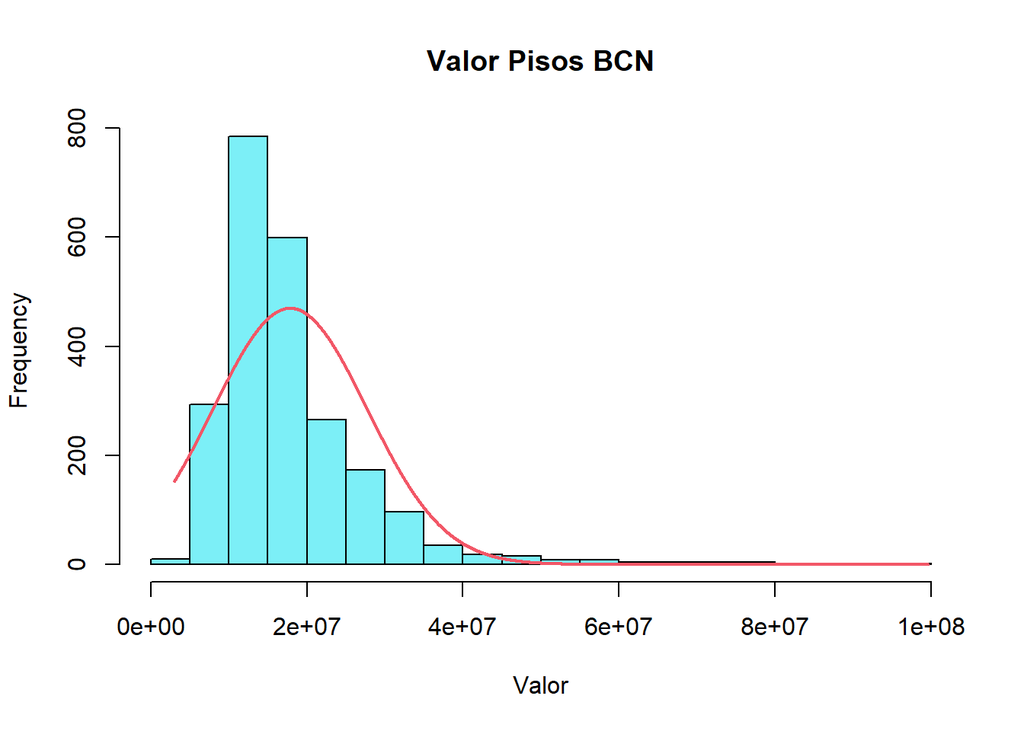

```r
x = BcnPisos$Valor
histValor = hist(x, breaks = 15, col="#7ceff7", xlab = "Valor", main = "Valor Pisos BCN")
xfit = seq(min(x), max(x), length(x))
yfit = dnorm(xfit, mean = mean(x), sd = sd(x))
yfit = yfit*diff(histValor$mids[1:2])*length(x)

lines(xfit, yfit, col="#f25767", lwd="2")
```

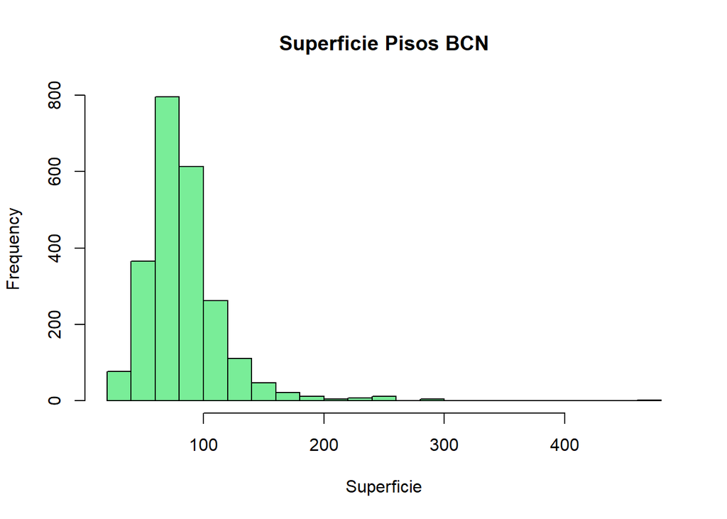

```r
######

x = BcnPisos$Superf
histSuperf = hist(x, breaks = 20, col="#79ed98", xlab = "Superficie", main = "Superficie Pisos BCN")
```

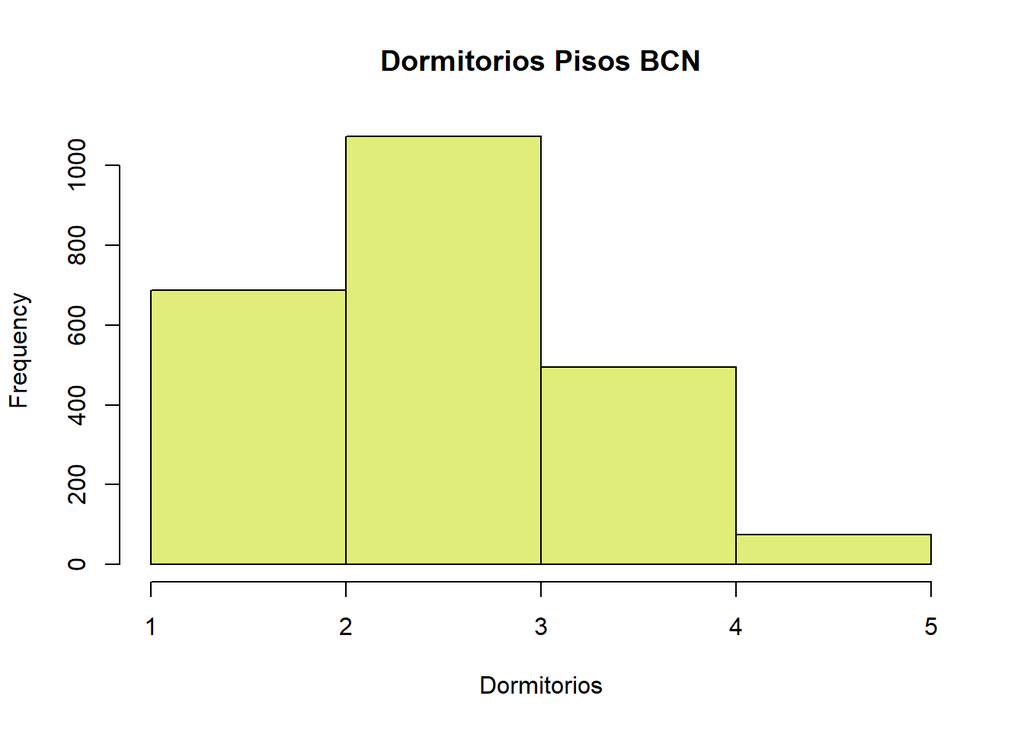

```r
######

x = BcnPisos$Dorm
histSuperf = hist(x, breaks = 5, col="#e1ed79", xlab = "Dormitorios", main = "Dormitorios Pisos BCN")
```

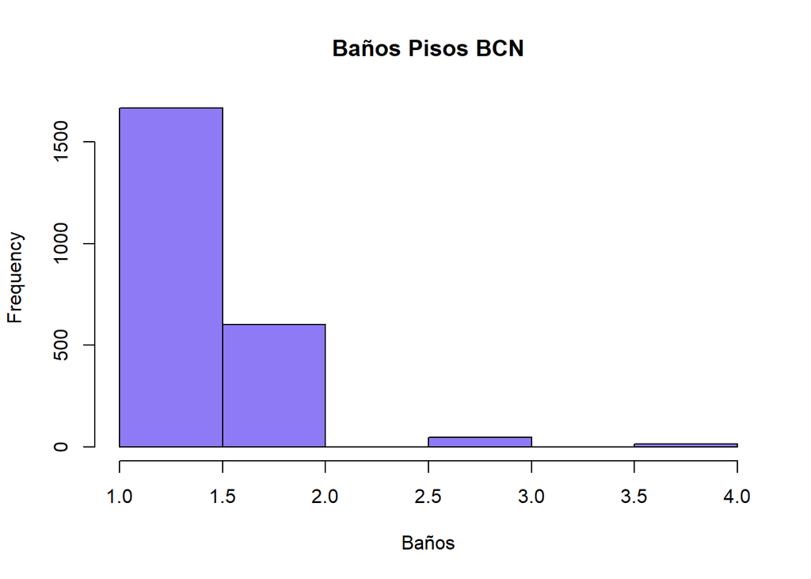

```r
######

x = BcnPisos$Banys
histSuperf = hist(x, breaks = 5, col="#8f7af5", xlab = "Baños", main = "Baños Pisos BCN")
```

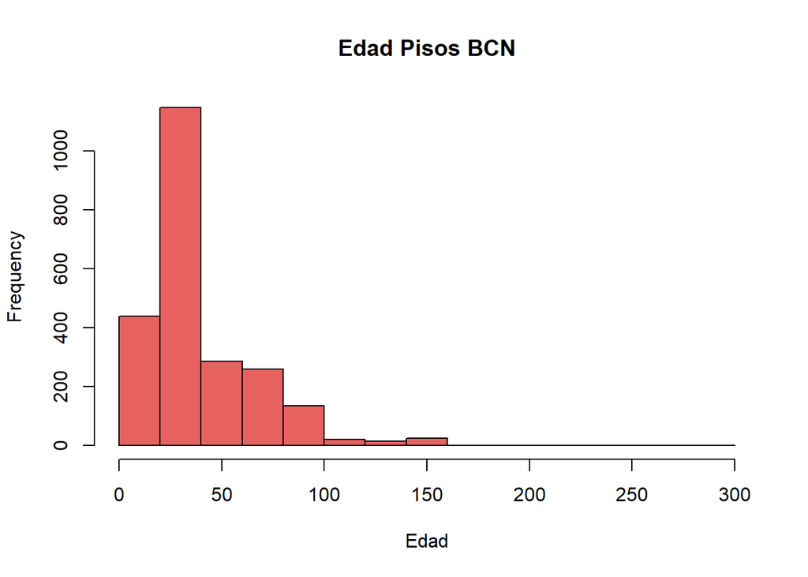

```r
######

x = BcnPisos$Edat
histSuperf = hist(x, breaks = 18, col="#e86161", xlab = "Edad", main = "Edad Pisos BCN")
```

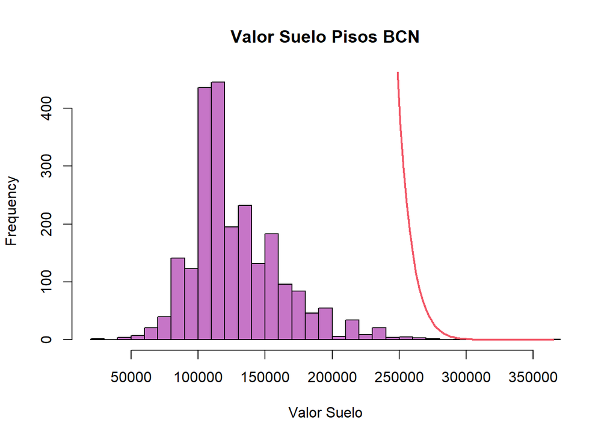

```r
######

x = BcnPisos$ValSol
histSuperf = hist(x, breaks = 30, col="#c675c7", xlab = "Valor Suelo", main = "Valor Suelo Pisos BCN")

xfit = seq(min(x), max(x), length(x))
yfit = dnorm(xfit, mean = mean(x), sd = sd(x))
yfit = yfit*diff(histValor$mids[1:2])*length(x)

lines(xfit, yfit, col="#f25767", lwd="2")
```

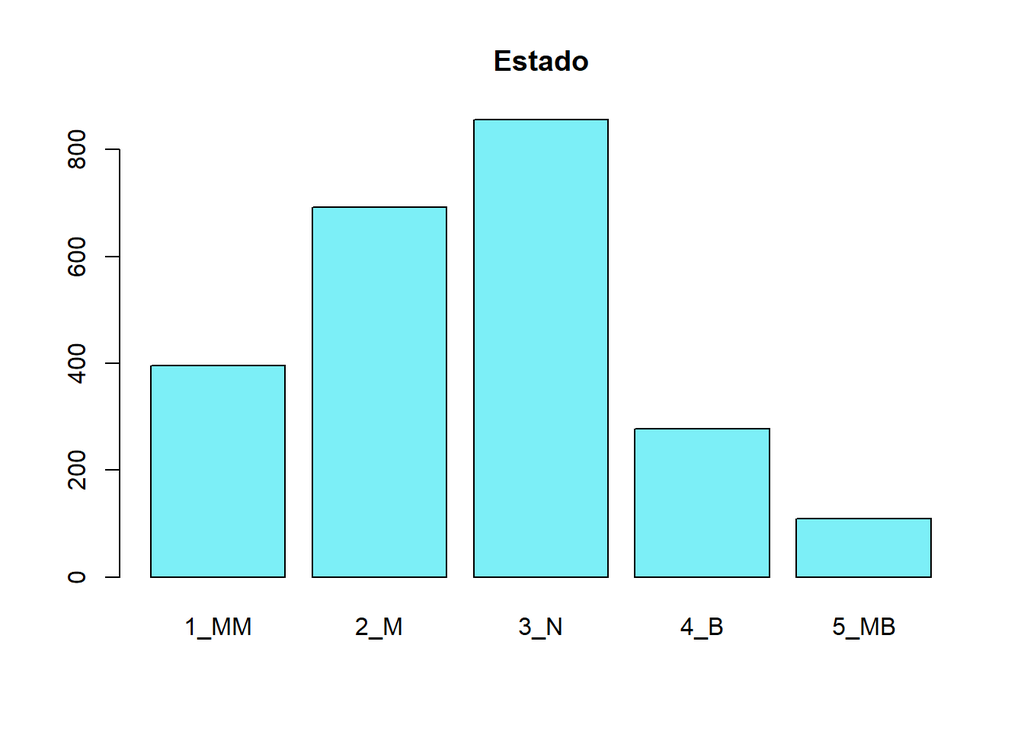

```r
y = table(BcnPisos$Estat)
barplot(y, col = "#7ceff7", main = "Estado")
```

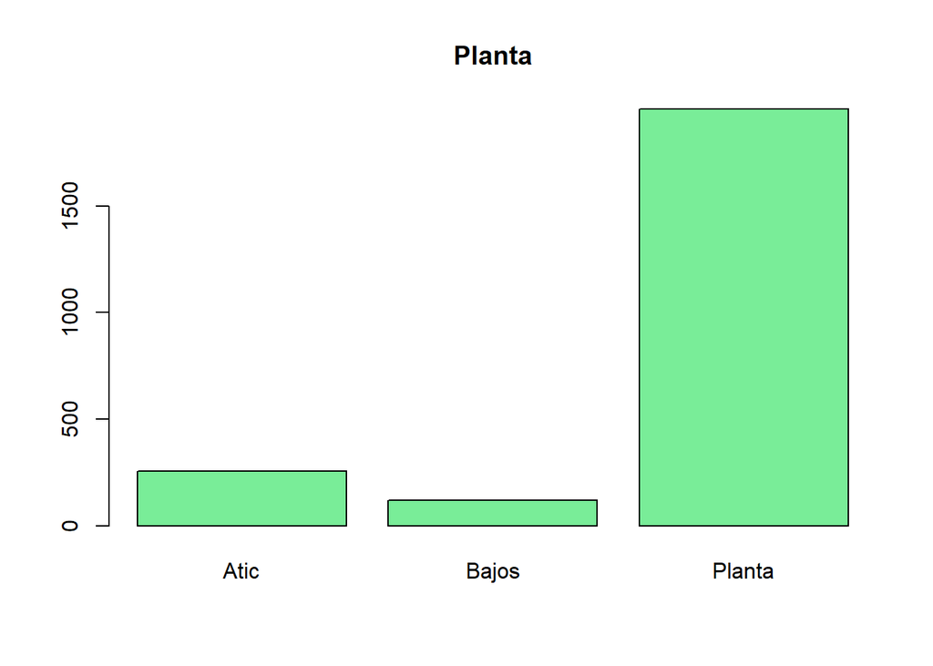

```r
######

y = table(BcnPisos$Planta)
barplot(y, col = "#79ed98", main = "Planta")
```

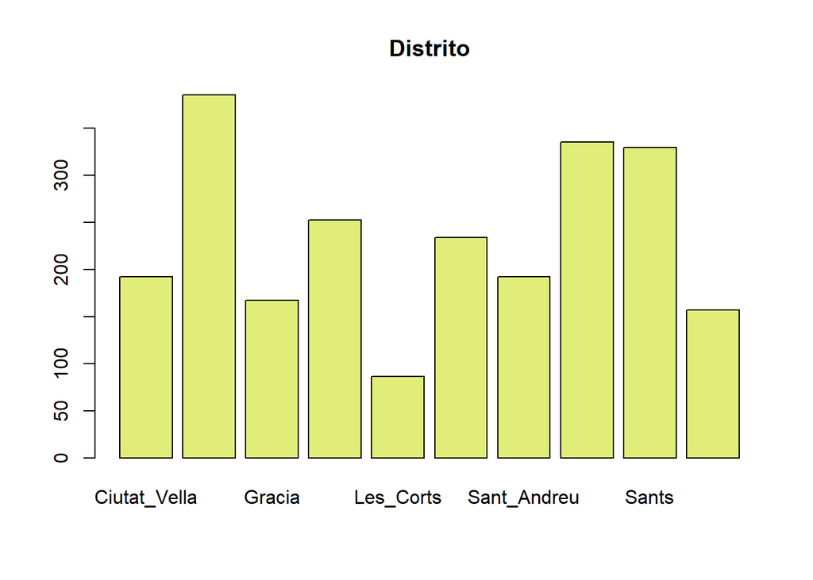

```r
######

y = table(BcnPisos$Dist)
barplot(y, col = "#e1ed79", main = "Distrito")
```

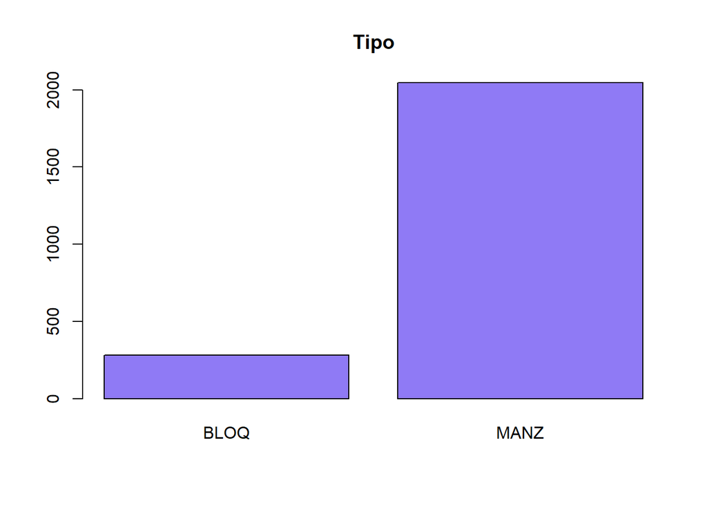

```r
######

y = table(BcnPisos$Tipus)
barplot(y, col = "#8f7af5", main = "Tipo")
```

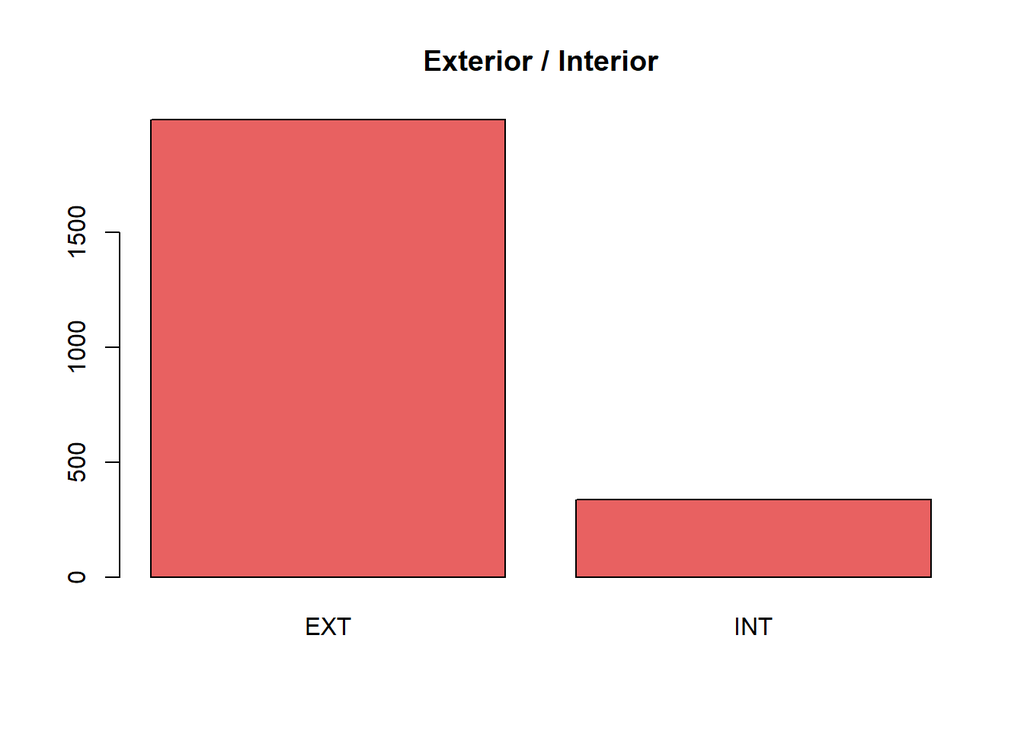

```r
######

y = table(BcnPisos$ExtInt)
barplot(y, col = "#e86161", main = "Exterior / Interior")
```

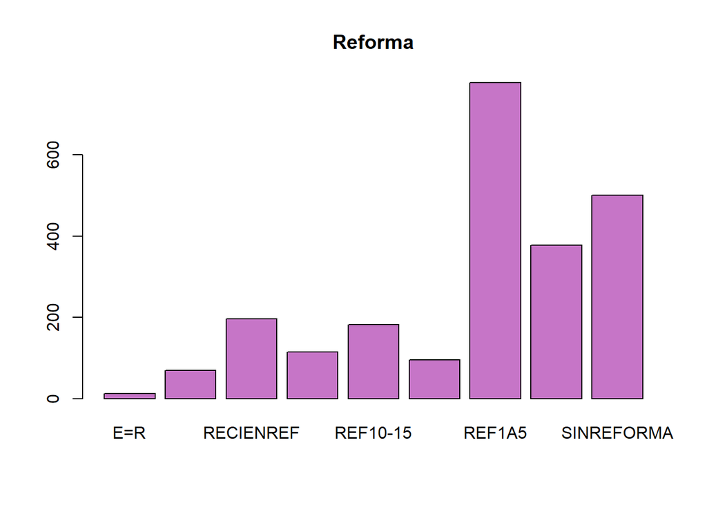

```r
######

y = table(BcnPisos$Reforma)
barplot(y, col = "#c675c7", main = "Reforma")
```

#### **7. Identifique si existe algún piso que podemos considerar “outlier” (para ello solo tenga en cuenta las variables continuas). Elimínelo del data frame.**

```r
BcnPisosOutliers = BcnPisos[,c(1:5,9)]  # Keep only continuous variables

outlier.scores = LOF(scale(BcnPisosOutliers), k=5) # Apply LOF to continuous variables

outliers = order(outlier.scores, decreasing = T)[1:10]  # Keep only top 10 Outliers

cbind(outlier.scores[outliers], BcnPisos[outliers,]) # Adding Outlier Score to dataframe
```

```
##      outlier.scores[outliers]    Valor Superf Dorm Banys Edat Estat Planta
## 217                       Inf 14015656  95.67    4     1   60  1_MM Planta
## 495                       Inf 15555000  91.50    4     1   80  1_MM Planta
## 714                       Inf 14796080  82.00    4     1   59  1_MM   Atic
## 975                       Inf 12180000  87.00    4     1   63   2_M Planta
## 1349                      Inf 17425000  85.00    4     1   70  1_MM Planta
## 1499                      Inf 14776144  94.64    4     1   57  1_MM Planta
## 2152                      Inf 18392504 105.10    4     1   70  1_MM Planta
## 112                  4.742961 80126080 475.30    5     2  289  1_MM Planta
## 441                  2.742498 14602500  88.50    4     3   32   3_N Planta
## 444                  2.728389 39312000 151.20    4     1   15   3_N Planta
##              Dist    ValSol Tipus Ascens ExtInt    Reforma
## 217         Sants 106679.20  MANZ     SI    EXT     REF>20
## 495        Gracia 113322.15  MANZ     SI    EXT     REF>20
## 714         Sants 106679.20  MANZ     NO    EXT     REF1A5
## 975    Sant_Marti 106679.20  MANZ     NO    EXT SINREFORMA
## 1349       Gracia 126608.05  MANZ     SI    EXT     REF>20
## 1499  Sant_Andreu 113322.15  MANZ     NO    EXT    REF5A10
## 2152     Eixample 126608.05  MANZ     SI    EXT     REF>20
## 112  Ciutat_Vella 166465.75  MANZ     NO    EXT  RECIENREF
## 441      Eixample  56192.78  MANZ     SI    EXT SINREFORMA
## 444      Eixample 166465.75  MANZ     SI    EXT     REF1A5
```

```r
BcnPisosNoOutliers = filter(BcnPisos, !row_number() %in% outliers) # Removing top 10 outliers
```

#### **8. Efectúe un diagrama bivariante (plot) entre el “Valor de los pisos” y su “Superficie”. Calcule la covariancia y la correlación entre ambas variables.**

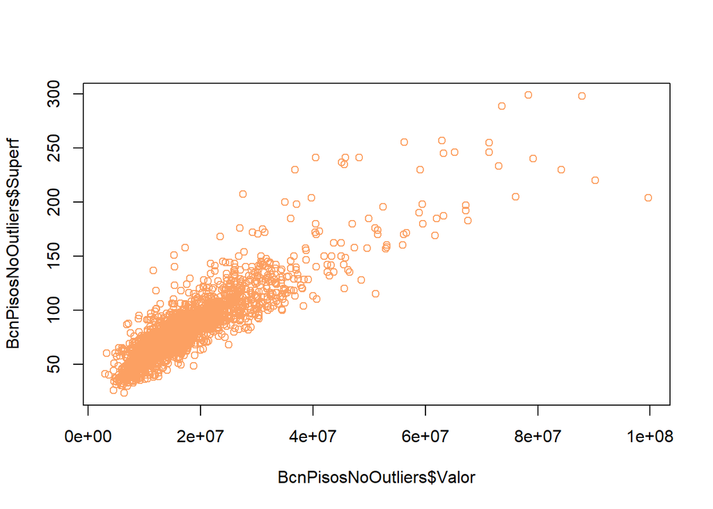

```r
# Scatter plot entre variables valor y superficie con descarte de los top 10 outliers

plot(BcnPisosNoOutliers$Valor, BcnPisosNoOutliers$Superf, col = '#fca062')
```

```r
cat("Covariance:",cov(BcnPisosNoOutliers$Valor, BcnPisosNoOutliers$Superf), "\nCorrelation:", cor(BcnPisosNoOutliers$Valor, BcnPisosNoOutliers$Superf))
```

```
## Covariance: 276400138
## Correlation: 0.8862507
```

Dada la correlación de 0.8862507 es muy próxima a 1, se puede determinar que existe una fuerte correlación entre el **Valor** del piso y su **Superficie**.

#### **9. Calcule la asociación entre el “Valor de los pisos” y el “Distrito”.**

```r
oneway.test(BcnPisosNoOutliers$Valor ~ BcnPisosNoOutliers$Dist, var.equal = T)
```

```
##
##  One-way analysis of means
##
## data:  BcnPisosNoOutliers$Valor and BcnPisosNoOutliers$Dist
## F = 123.37, num df = 9, denom df = 2309, p-value < 2.2e-16
```

Al obtener un valor F mucho mayor a 1, sugiere que existe una relación entre las variables *Valor* y *Distrito*. Tomando en cuenta el valor F y p-value (el cual es cercano a cero y menor que 0.01) podemos concluir que las variables son dependientes aceptando h1 y rechazando h0.

#### **10. Calcule la asociación entre el “Distrito” y el “Estado de la vivienda”.**

```r
DistVsEstat = table(BcnPisosNoOutliers$Dist, BcnPisosNoOutliers$Estat)

xSquared = chisq.test(DistVsEstat)
print(xSquared)
```

```
##
##  Pearson's Chi-squared test
##
## data:  DistVsEstat
## X-squared = 161.85, df = 36, p-value < 2.2e-16
```

```r
criticalValue = qchisq(0.99, df = xSquared$parameter)

cat("Es Chi Cuadrado mayor que el valor critico?:", xSquared$statistic > criticalValue)
```

```
## Es Chi Cuadrado mayor que el valor critico?: TRUE
```

Dado que el chi-cuadrado es mayor que el critical value, podemos rechazar h0 y aceptar h1 ya que sugiere una correlación entre **Distrito** y **Estado de la vivienda** reforzado por un p-value próximo a cero y menor que 0.01.